code for analyzing the associations between milk production or somatic cell count and temperature among dairy cattle in Fort Collins Load required libraries

```r
library(foreign)
library(stats)
library(splines)
library(mgcv)
library(tidyverse)
library(readxl)
library(writexl)
```

```r
library(ggplot2)
library(ggcorrplot)
library(ggthemes)
library(nlme)
```

For ggplots

```r
simple_theme <- theme(
  #aspect.ratio = 1,
  text  = element_text(family="Calibri",size = 12, color = 'black'),
  panel.spacing.y = unit(0,"cm"),
  panel.spacing.x = unit(0.25, "lines"),
  panel.grid.minor = element_line(color = "transparent"),
  panel.grid.major = element_line(color = "transparent"),
  panel.border=element_rect(fill = NA),
  panel.background=element_blank(),
  axis.ticks = element_line(colour = "black"),
  axis.text = element_text(color = "black", size=10),
  # legend.position = c(0.1,0.1),
  plot.margin=grid::unit(c(0,0,0,0), "mm"),
  legend.key = element_blank()
)
windowsFonts(Calibri=windowsFont("TT Calibri"))
options(scipen = 9999) #avoid scientific notation
```

| Load production data, and merge with SCC data |
| --- |

```r
dairy_data <- read_csv(here::here("Data", "052019_to_062019_Production_FC_Data.csv"))
glimpse(dairy_data)
```

```
## Observations: 61
## Variables: 6
## $ DATE                 <chr> "5/1/2019", "5/2/2019", "5/3/2019", "5/4/...
## $ Avgmilk              <dbl> 86.0, 84.9, 87.2, 86.5, 87.6, 87.7, 86.4,...
## $ FOOTHILLS_DAILYMAXO3 <dbl> 42, 47, 61, 60, 58, 51, 16, 32, 36, 38, 4...
## $ PM2.5_avg            <dbl> 2.458333, 6.041667, 5.166667, 5.291667, 4...
## $ PM2.5_max            <dbl> 4, 9, 10, 12, 7, 21, 9, 5, 12, 13, 12, 6,...
## $ THI                  <dbl> NA, 41.42400, 49.84950, 52.39400, 61.0770...
```

```r
scc_data <- read_csv(here::here("Data", "05&062019_FCSCC.csv"))
glimpse(scc_data)
```

```
## Observations: 61
## Variables: 2
## $ DATE    <chr> "5/1/2019", "5/2/2019", "5/3/2019", "5/4/2019", "5/5/2...
## $ SCC_avg <dbl> 95.50000, 88.00000, 97.00000, 98.50000, 99.00000, 89.6...
```

```r
dairy_data <- left_join(dairy_data, scc_data, by = "DATE") %>%
  mutate(DATE = as.Date(DATE, format = "%m/%d/%Y"))

head(dairy_data)
```

```
## # A tibble: 6 x 7
##   DATE       Avgmilk FOOTHILLS_DAILYMAXO3 PM2.5_avg PM2.5_max   THI SCC_avg
##   <date>       <dbl>                <dbl>     <dbl>     <dbl> <dbl>   <dbl>
## 1 2019-05-01    86                     42      2.46         4  NA      95.5
## 2 2019-05-02    84.9                   47      6.04         9  41.4    88
## 3 2019-05-03    87.2                   61      5.17        10  49.8    97
## 4 2019-05-04    86.5                   60      5.29        12  52.4    98.5
## 5 2019-05-05    87.6                   58      4.54         7  61.1    99
## 6 2019-05-06    87.7                   51     11.9         21  56.1    89.7
```

```r
summary(dairy_data)
```

```
##       DATE               Avgmilk      FOOTHILLS_DAILYMAXO3
##  Min.   :2019-05-01   Min.   :83.40   Min.   :16.00
##  1st Qu.:2019-05-16   1st Qu.:87.20   1st Qu.:46.00
##  Median :2019-05-31   Median :88.40   Median :53.00
##  Mean   :2019-05-31   Mean   :88.41   Mean   :51.77
##  3rd Qu.:2019-06-15   3rd Qu.:90.00   3rd Qu.:59.00
##  Max.   :2019-06-30   Max.   :92.30   Max.   :71.00
##                                       NA's   :4
##    PM2.5_avg        PM2.5_max          THI           SCC_avg
##  Min.   : 0.500   Min.   : 2.00   Min.   :25.77   Min.   : 72.00
##  1st Qu.: 2.667   1st Qu.: 6.00   1st Qu.:51.69   1st Qu.: 84.00
##  Median : 4.083   Median : 7.00   Median :62.69   Median : 88.50
##  Mean   : 4.297   Mean   : 8.23   Mean   :58.86   Mean   : 89.74
##  3rd Qu.: 5.333   3rd Qu.:10.00   3rd Qu.:68.11   3rd Qu.: 96.50
##  Max.   :11.875   Max.   :26.00   Max.   :86.47   Max.   :110.00
##                                   NA's   :4
```

Examining each variable Histograms and time series plots Correlations between each variable Check autocorrelation

Average milk production

`r ggplot(dairy_data) + geom_histogram(aes(x = Avgmilk)) + simple_theme`

`` ## `stat_bin()` using `bins = 30`. Pick better value with `binwidth`. ``

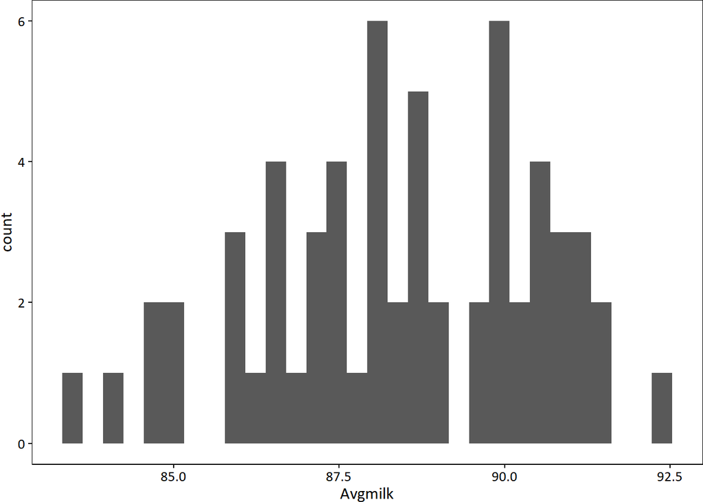

`r ggplot(dairy_data) + geom_point(aes(x = DATE, y = Avgmilk)) + simple_theme`

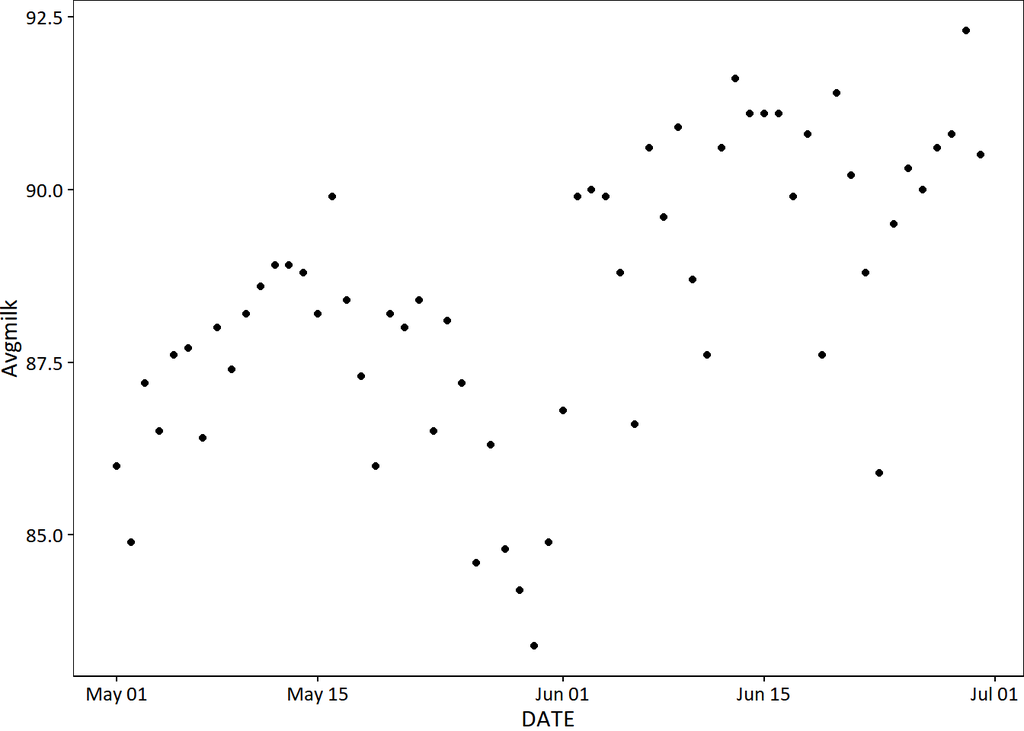

`r acf(dairy_data$Avgmilk, plot = T)`

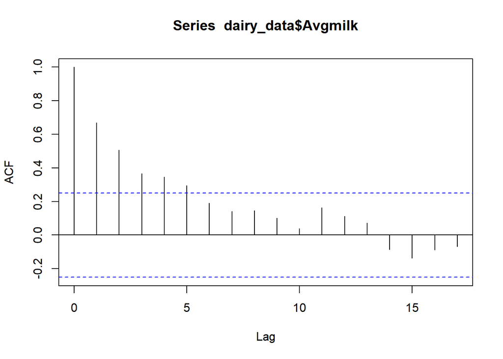

`r pacf(dairy_data$Avgmilk, plot = T)`

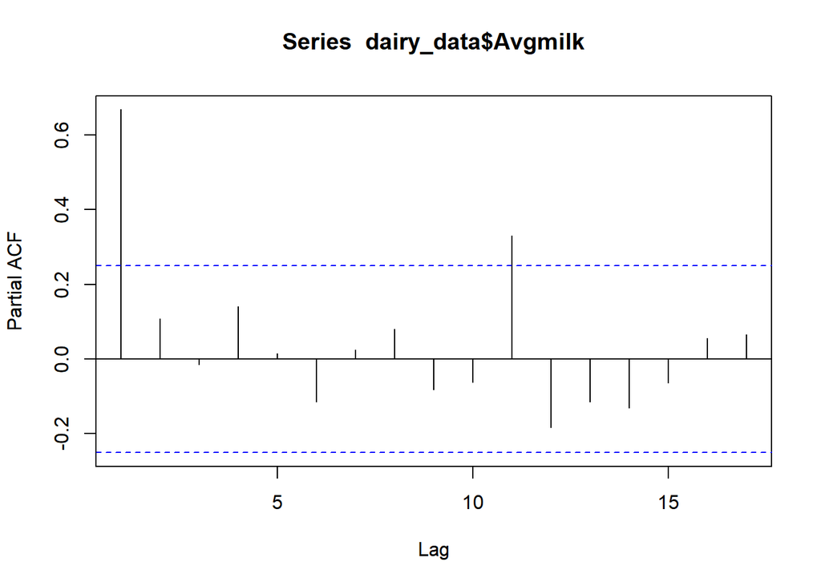

Somatic cell counts

`r ggplot(dairy_data) + geom_histogram(aes(x = SCC_avg)) + simple_theme`

`` ## `stat_bin()` using `bins = 30`. Pick better value with `binwidth`. ``

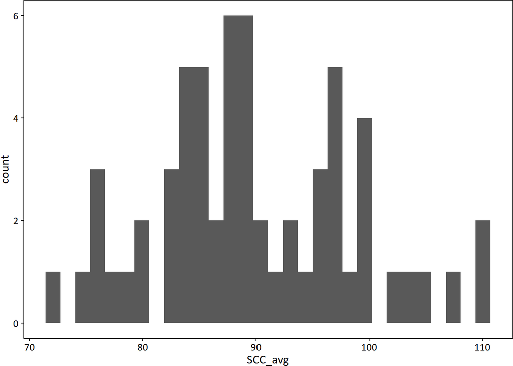

`r ggplot(dairy_data) + geom_point(aes(x = DATE, y = SCC_avg)) + simple_theme`

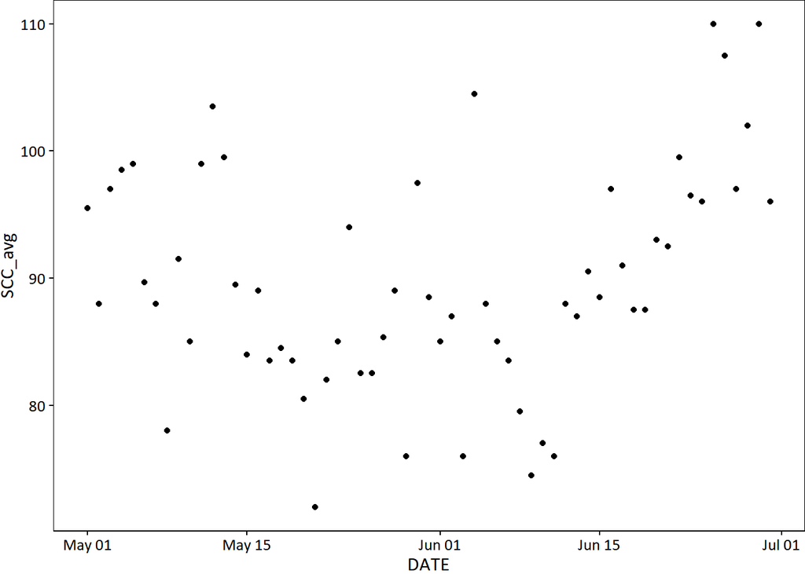

`r acf(dairy_data$SCC_avg, plot = T)`

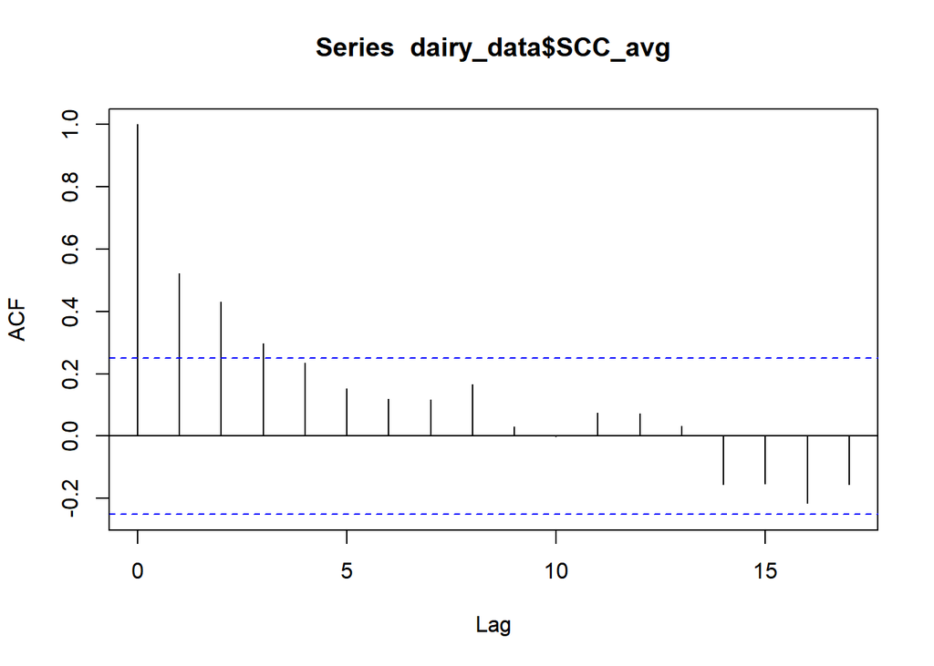

`r pacf(dairy_data$SCC_avg, plot = T)`

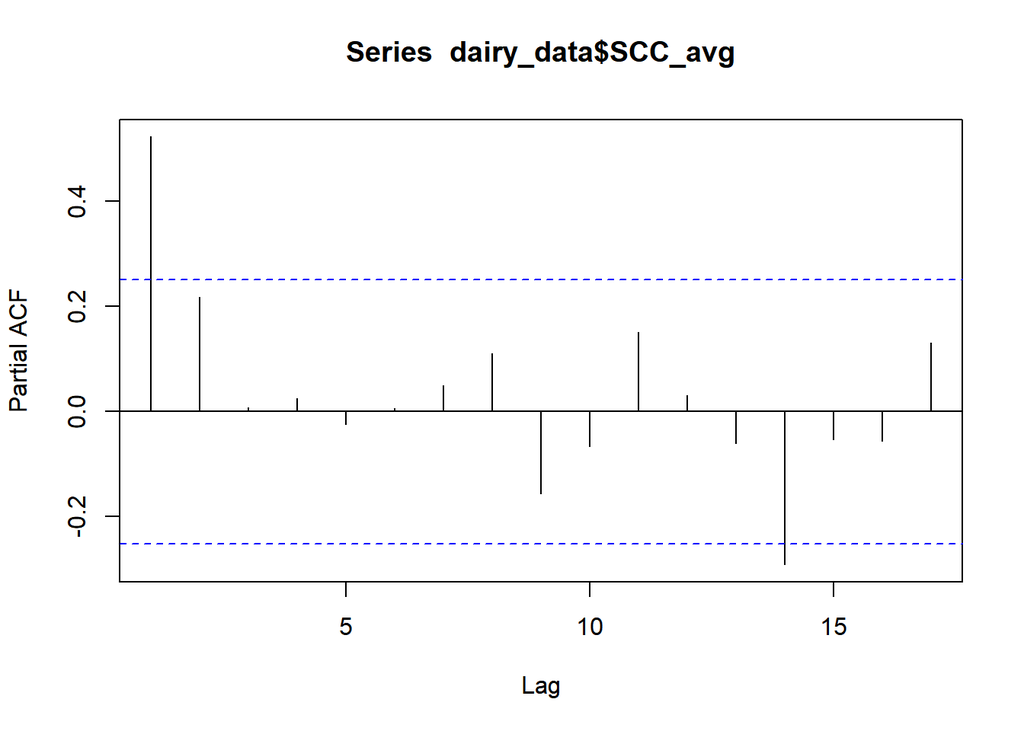

Temperature

`r ggplot(dairy_data) + geom_histogram(aes(x = THI)) + simple_theme`

`` ## `stat_bin()` using `bins = 30`. Pick better value with `binwidth`. ``

`## Warning: Removed 4 rows containing non-finite values (stat_bin).`

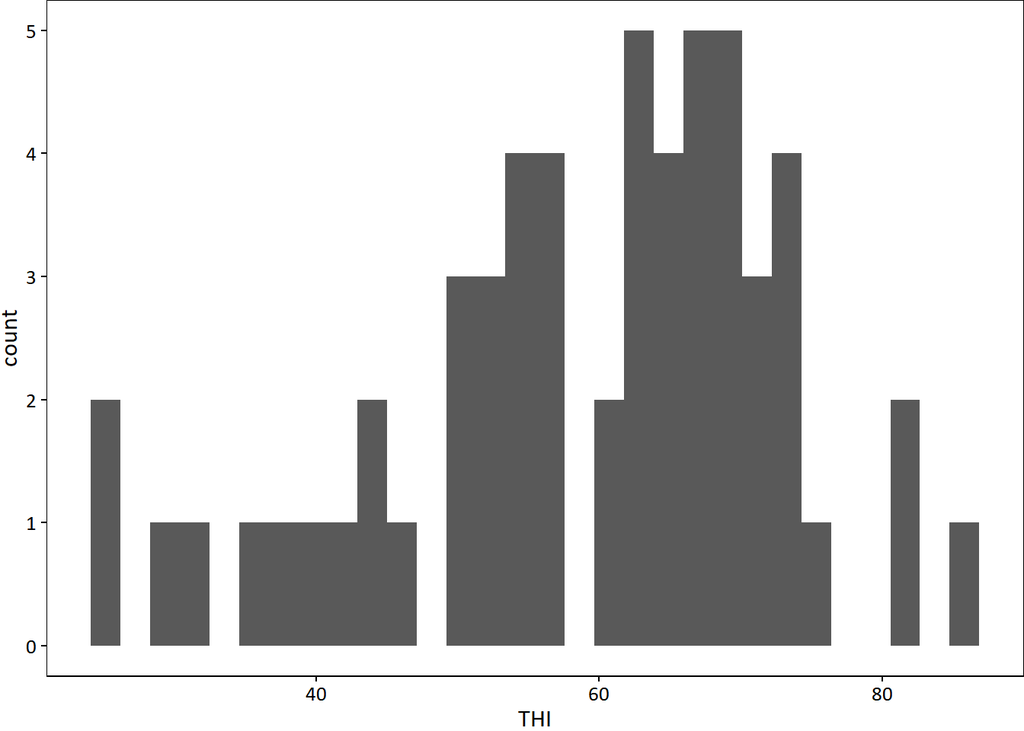

`r ggplot(dairy_data) + geom_point(aes(x = DATE, y = THI)) + simple_theme`

`## Warning: Removed 4 rows containing missing values (geom_point).`

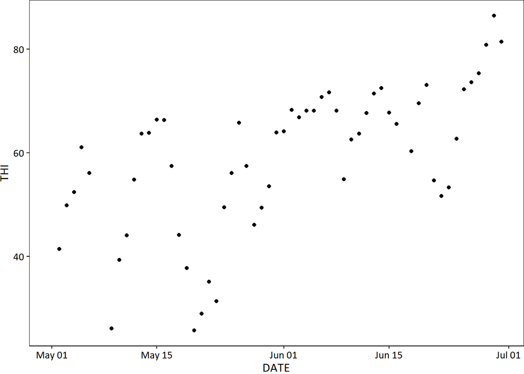

`r acf(dairy_data$THI, plot = T, na.action = na.pass)`

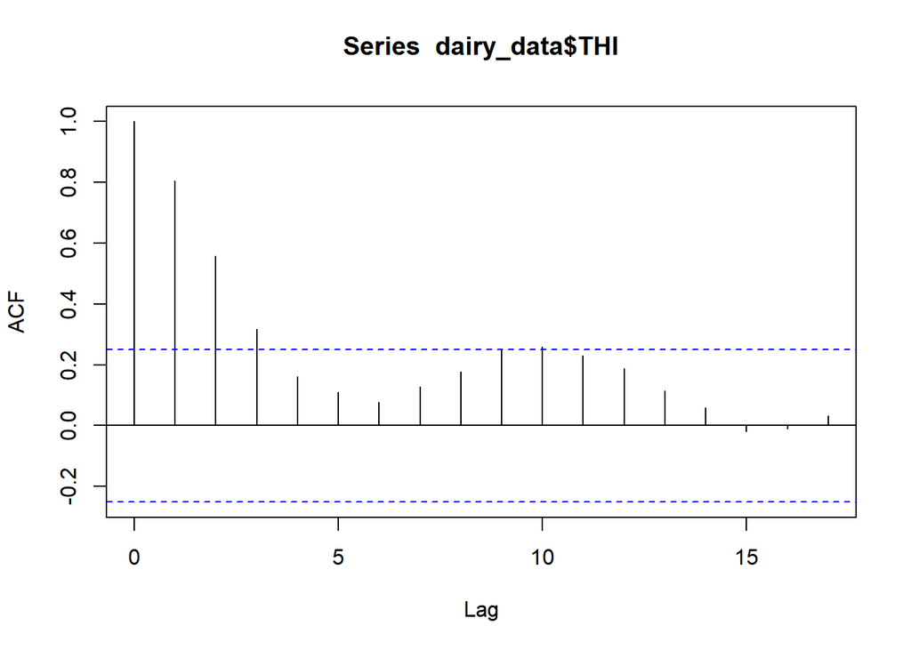

`r pacf(dairy_data$THI, plot = T, na.action = na.pass)`

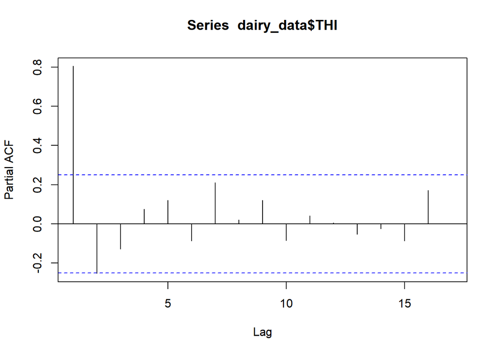

Ozone

`r ggplot(dairy_data) + geom_histogram(aes(x = FOOTHILLS_DAILYMAXO3)) + simple_theme`

`` ## `stat_bin()` using `bins = 30`. Pick better value with `binwidth`. ``

`## Warning: Removed 4 rows containing non-finite values (stat_bin).`

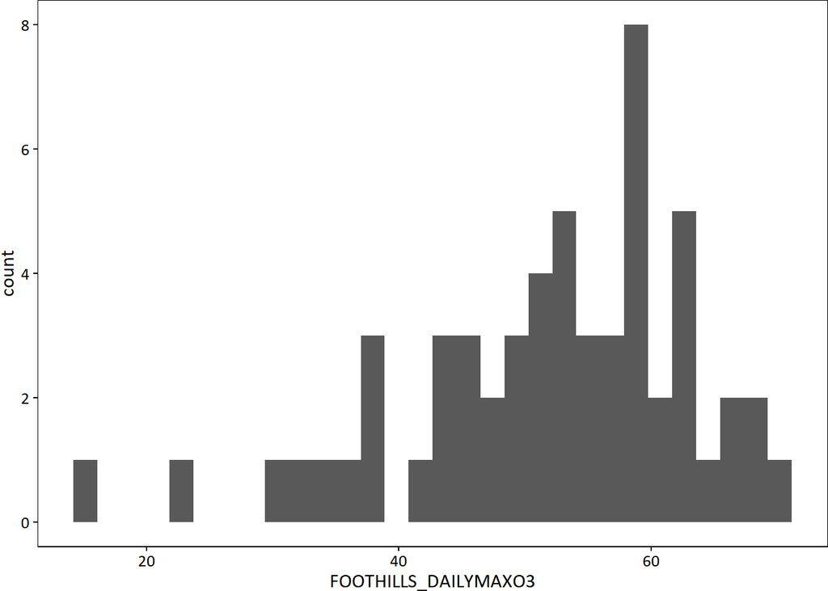

`r ggplot(dairy_data) + geom_point(aes(x = DATE, y = FOOTHILLS_DAILYMAXO3)) + simple_theme`

`## Warning: Removed 4 rows containing missing values (geom_point).`

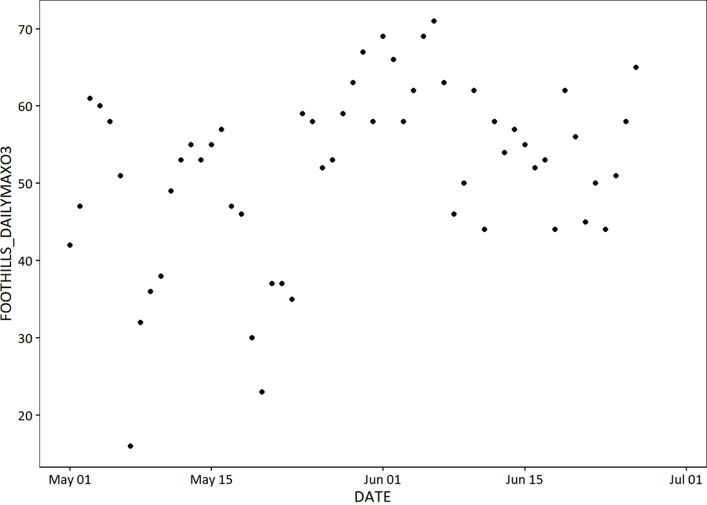

`r acf(dairy_data$FOOTHILLS_DAILYMAXO3, plot = T, na.action = na.pass)`

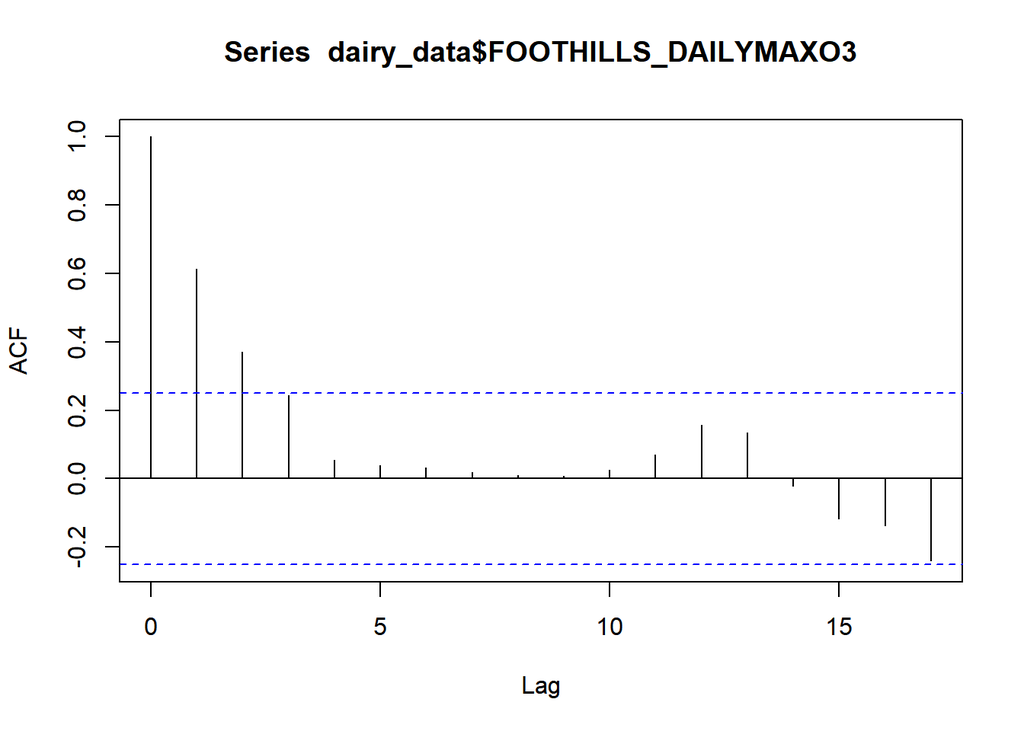

`r pacf(dairy_data$FOOTHILLS_DAILYMAXO3, plot = T, na.action = na.pass)`

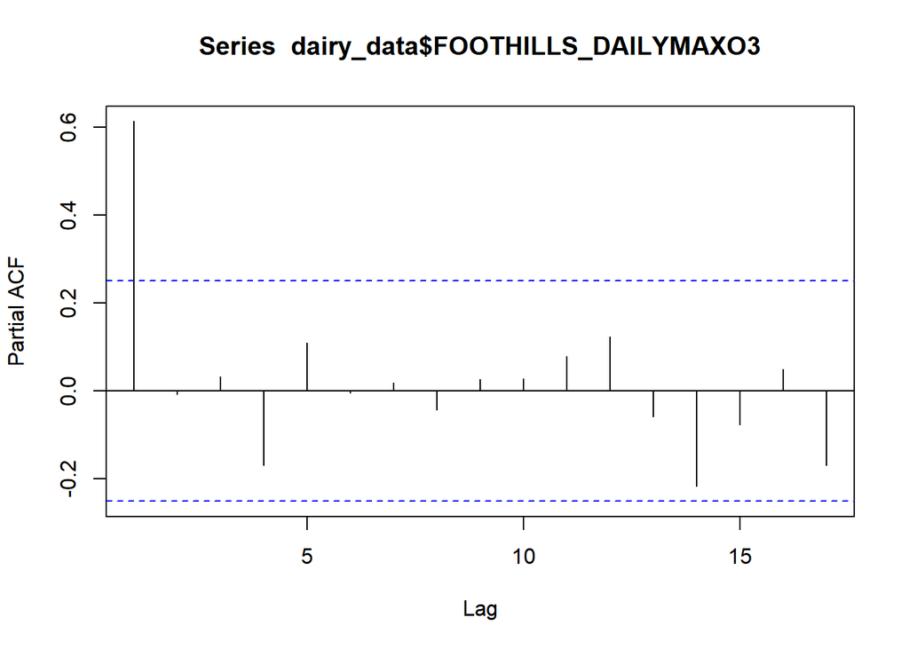

24 h mean PM

`r ggplot(dairy_data) + geom_histogram(aes(x = PM2.5_avg)) + simple_theme`

`` ## `stat_bin()` using `bins = 30`. Pick better value with `binwidth`. ``

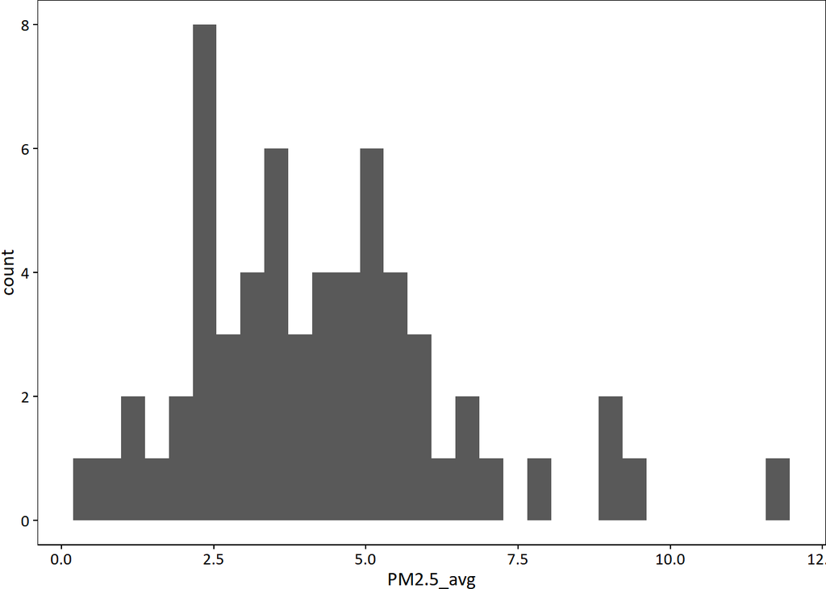

`r ggplot(dairy_data) + geom_point(aes(x = DATE, y = PM2.5_avg)) + simple_theme`

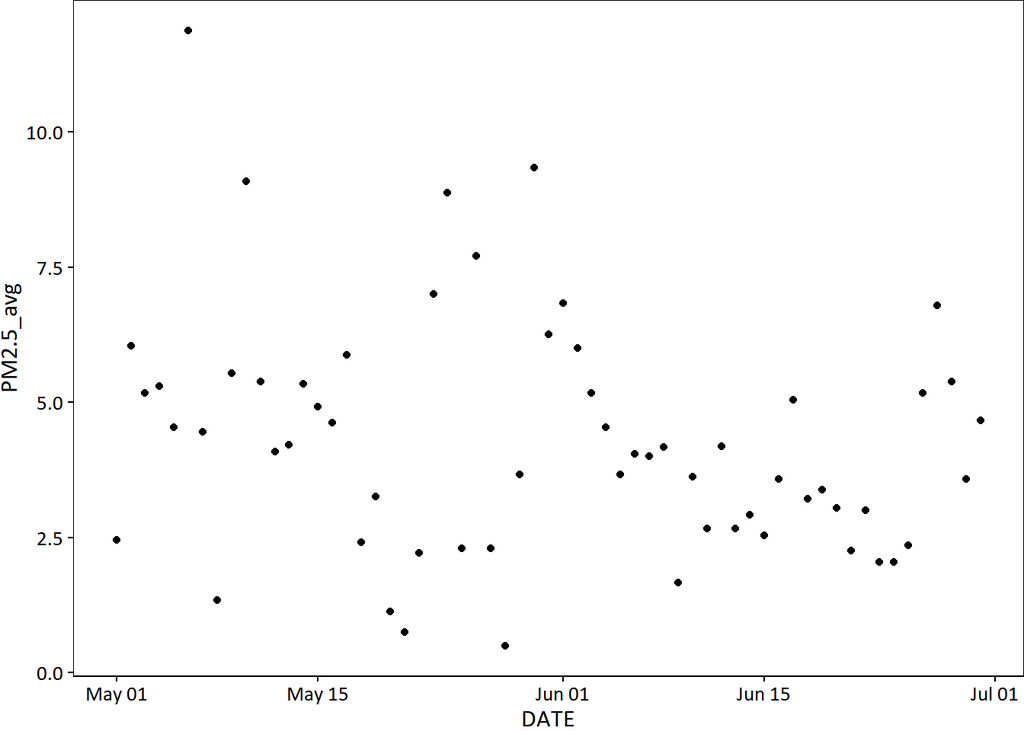

`r acf(dairy_data$PM2.5_avg, plot = T, na.action = na.pass)`

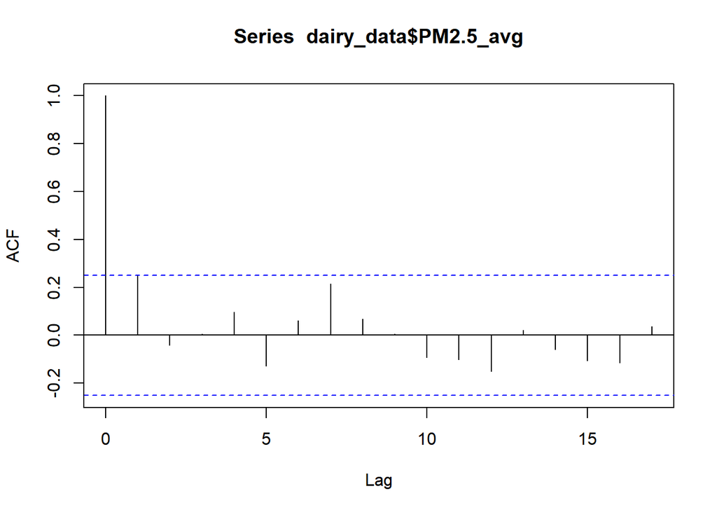

`r pacf(dairy_data$PM2.5_avg, plot = T, na.action = na.pass)`

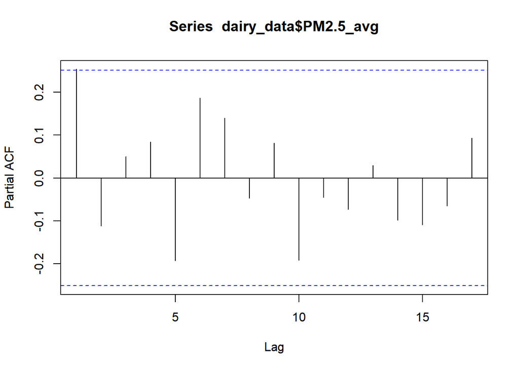

1 hour max PM2.5

`r ggplot(dairy_data) + geom_histogram(aes(x = PM2.5_max)) + simple_theme`

`` ## `stat_bin()` using `bins = 30`. Pick better value with `binwidth`. ``

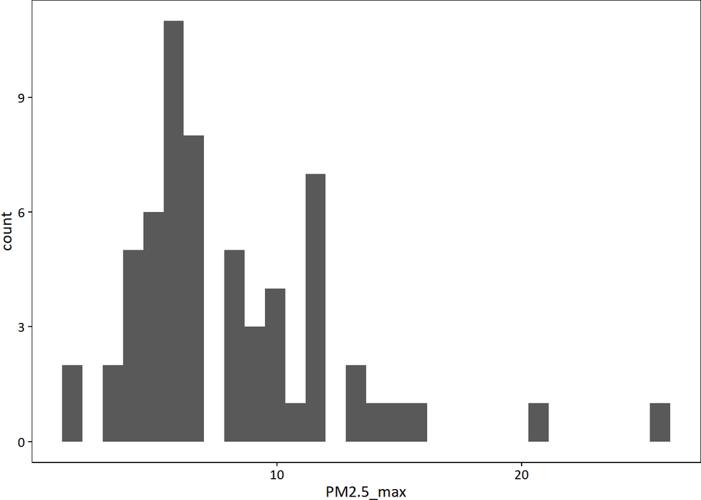

`r ggplot(dairy_data) + geom_point(aes(x = DATE, y = PM2.5_max)) + simple_theme`

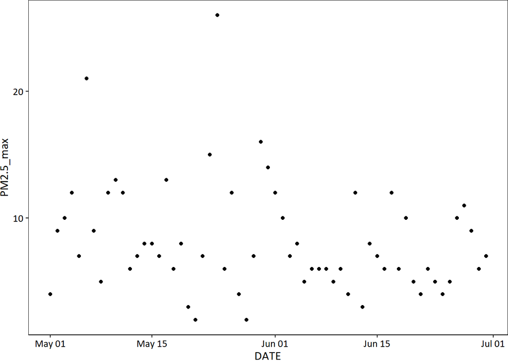

`r acf(dairy_data$PM2.5_max, plot = T, na.action = na.pass)`

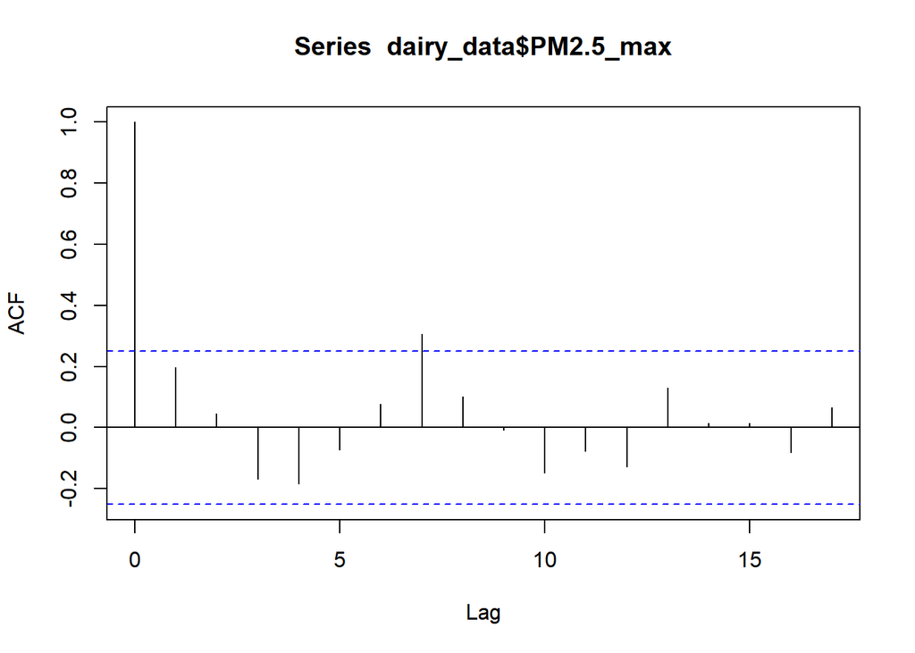

`r pacf(dairy_data$PM2.5_max, plot = T, na.action = na.pass)`

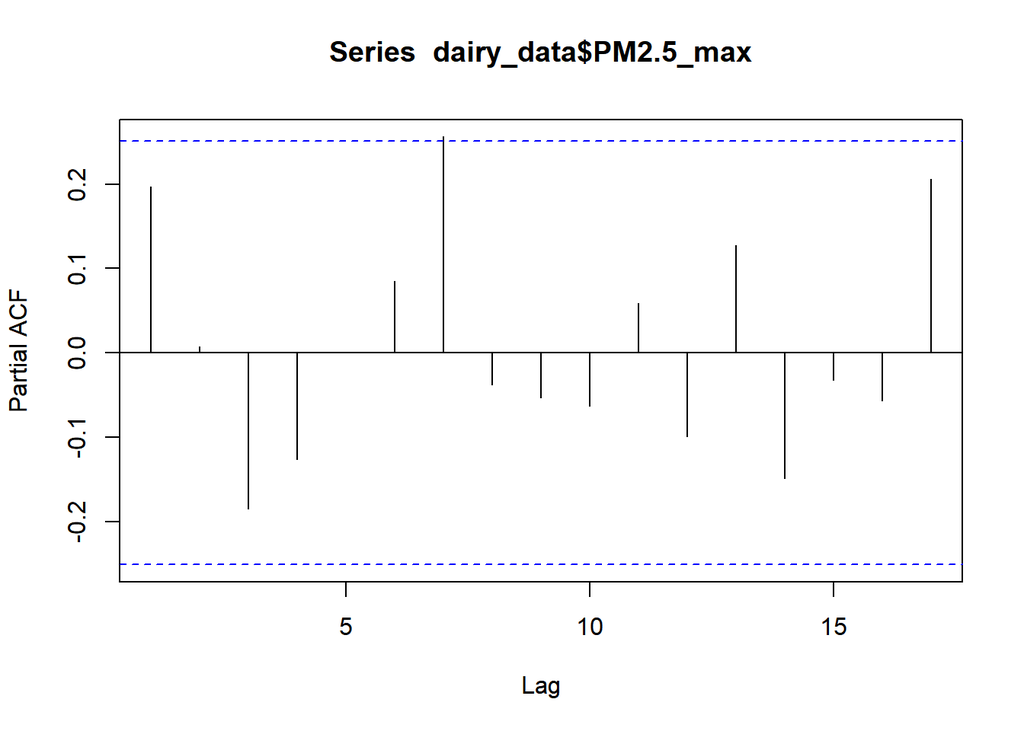

Correlation coefficients between the variables PM2.5 mean and max are very highly correlated

`r var_cor <- select(dairy_data, -DATE) %>% na.omit() ggcorrplot(round(cor(var_cor), 1), outline.col = "white", lab = T, colors = c("#6D9EC1", "white", "#E46726"))`

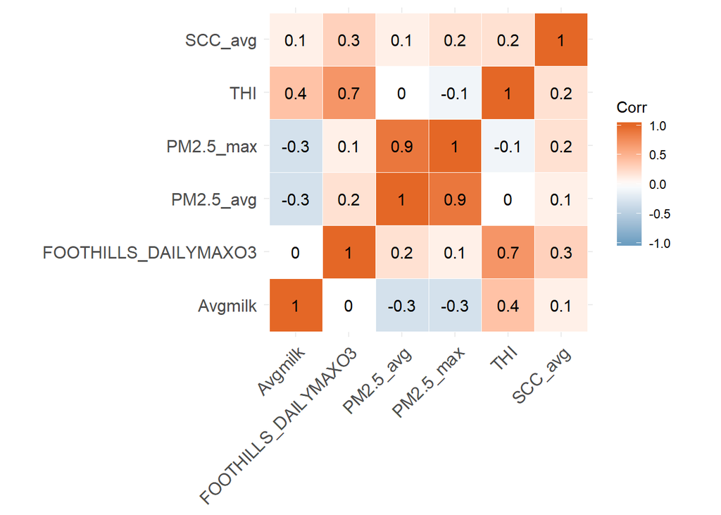

## First, linear regression models for milk production

Just the date

```r
prod_lm_0 <- lm(Avgmilk ~ DATE, data = dairy_data)
summary(prod_lm_0)
```

```
##
## Call:
## lm(formula = Avgmilk ~ DATE, data = dairy_data)
##
## Residuals:
##     Min      1Q  Median      3Q     Max
## -4.9457 -0.8252  0.4439  1.3619  2.4518
##
## Coefficients:
##                Estimate  Std. Error t value   Pr(>|t|)
## (Intercept) -1068.56415   230.36910  -4.638 0.00001996 ***
## DATE            0.06411     0.01276   5.022 0.00000502 ***
## ---
## Signif. codes:  0 '***' 0.001 '**' 0.01 '*' 0.05 '.' 0.1 ' ' 1
##
## Residual standard error: 1.755 on 59 degrees of freedom
## Multiple R-squared:  0.2995, Adjusted R-squared:  0.2876
## F-statistic: 25.22 on 1 and 59 DF,  p-value: 0.000005024
```

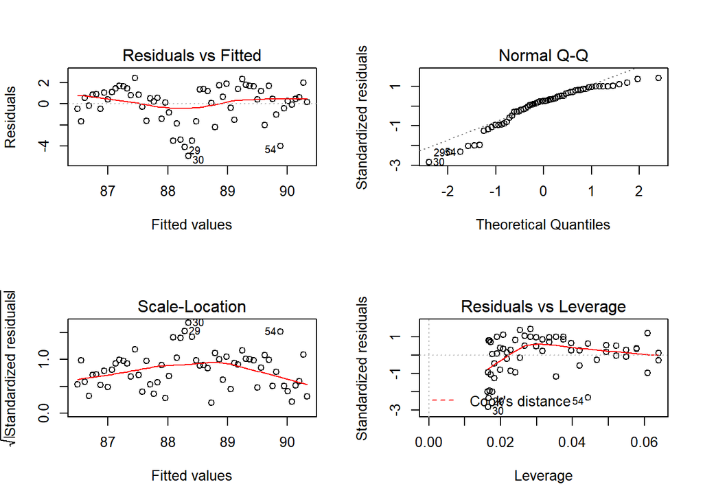

```r
par(mfrow = c(2,2))
plot(prod_lm_0)
```

```r
par(mfrow = c(1,1))
```

Add temperature

```r
prod_lm_1 <- lm(Avgmilk ~ THI, data = dairy_data)
summary(prod_lm_1)
```

```
##
## Call:
## lm(formula = Avgmilk ~ THI, data = dairy_data)
##
## Residuals:
##     Min      1Q  Median      3Q     Max
## -4.6459 -1.0441  0.3745  1.3042  2.7478
##
## Coefficients:
##             Estimate Std. Error t value             Pr(>|t|)
## (Intercept) 83.81056    1.04398  80.280 < 0.0000000000000002 ***
## THI          0.07914    0.01727   4.583            0.0000268 ***
## ---
## Signif. codes:  0 '***' 0.001 '**' 0.01 '*' 0.05 '.' 0.1 ' ' 1
##
## Residual standard error: 1.803 on 55 degrees of freedom
##   (4 observations deleted due to missingness)
## Multiple R-squared:  0.2764, Adjusted R-squared:  0.2632
## F-statistic: 21.01 on 1 and 55 DF,  p-value: 0.00002677
```

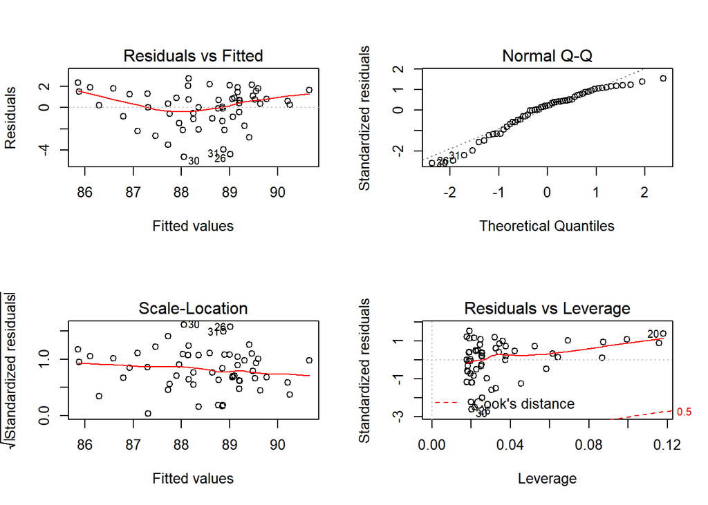

```r
par(mfrow = c(2,2))
plot(prod_lm_1)
```

```r
par(mfrow = c(1,1))
```

Add ozone

```r
prod_lm_2 <- lm(Avgmilk ~ THI + FOOTHILLS_DAILYMAXO3, data = dairy_data)
summary(prod_lm_2)
```

```
##
## Call:
## lm(formula = Avgmilk ~ THI + FOOTHILLS_DAILYMAXO3, data = dairy_data)
##
## Residuals:
##     Min      1Q  Median      3Q     Max
## -4.9809 -1.0308  0.5761  1.2443  2.5870
##
## Coefficients:
##                      Estimate Std. Error t value             Pr(>|t|)
## (Intercept)          86.77965    1.21974  71.146 < 0.0000000000000002 ***
## THI                   0.13835    0.02520   5.490           0.00000134 ***
## FOOTHILLS_DAILYMAXO3 -0.12114    0.03182  -3.807             0.000386 ***
## ---
## Signif. codes:  0 '***' 0.001 '**' 0.01 '*' 0.05 '.' 0.1 ' ' 1
##
## Residual standard error: 1.642 on 50 degrees of freedom
##   (8 observations deleted due to missingness)
## Multiple R-squared:  0.3763, Adjusted R-squared:  0.3514
## F-statistic: 15.09 on 2 and 50 DF,  p-value: 0.000007477
```

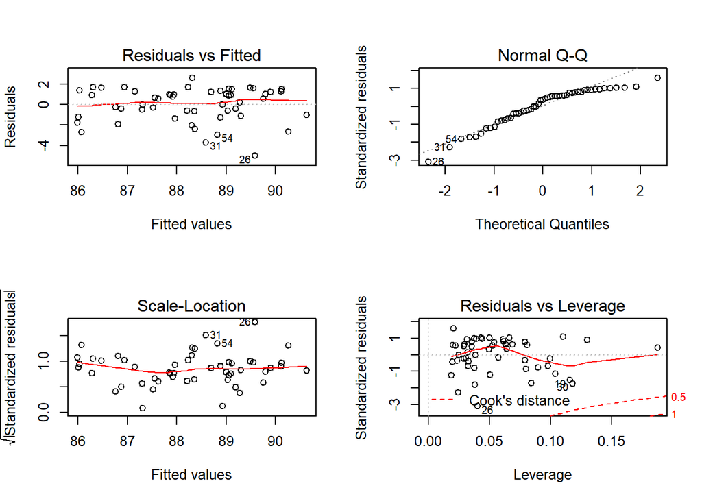

```r
par(mfrow = c(2,2))
plot(prod_lm_2)
```

```r
par(mfrow = c(1,1))
```

Add daily PM2.5 average

```r
prod_lm_3 <- lm(Avgmilk ~ THI + FOOTHILLS_DAILYMAXO3 + PM2.5_avg,
              data = dairy_data)
summary(prod_lm_3)
```

```
##
## Call:
## lm(formula = Avgmilk ~ THI + FOOTHILLS_DAILYMAXO3 + PM2.5_avg,
##     data = dairy_data)
##
## Residuals:
##     Min      1Q  Median      3Q     Max
## -4.3370 -0.8704  0.5785  1.1496  2.2333
##
## Coefficients:
##                      Estimate Std. Error t value             Pr(>|t|)
## (Intercept)          87.20308    1.22876  70.969 < 0.0000000000000002 ***
## THI                   0.13045    0.02528   5.160           0.00000446 ***
## FOOTHILLS_DAILYMAXO3 -0.10715    0.03249  -3.297              0.00182 **
## PM2.5_avg            -0.16543    0.10232  -1.617              0.11237
## ---
## Signif. codes:  0 '***' 0.001 '**' 0.01 '*' 0.05 '.' 0.1 ' ' 1
##
## Residual standard error: 1.617 on 49 degrees of freedom
##   (8 observations deleted due to missingness)
## Multiple R-squared:  0.4079, Adjusted R-squared:  0.3717
## F-statistic: 11.25 on 3 and 49 DF,  p-value: 0.000009865
```

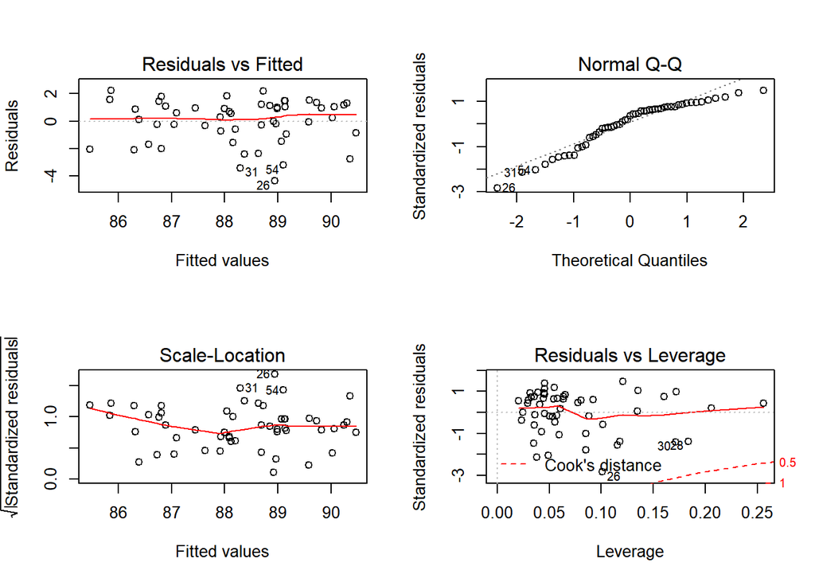

```r
par(mfrow = c(2,2))
plot(prod_lm_3)
```

```r
par(mfrow = c(1,1))
```

Swap for daily PM max

```r
prod_lm_4 <- lm(Avgmilk ~ THI + FOOTHILLS_DAILYMAXO3 + PM2.5_max,
              data = dairy_data)
summary(prod_lm_4)
```

```
##
## Call:
## lm(formula = Avgmilk ~ THI + FOOTHILLS_DAILYMAXO3 + PM2.5_max,
##     data = dairy_data)
##
## Residuals:
##     Min      1Q  Median      3Q     Max
## -4.7313 -1.0001  0.4484  1.1868  2.4389
##
## Coefficients:
##                      Estimate Std. Error t value             Pr(>|t|)
## (Intercept)          87.10613    1.27280  68.436 < 0.0000000000000002 ***
## THI                   0.13124    0.02641   4.969           0.00000862 ***
## FOOTHILLS_DAILYMAXO3 -0.11207    0.03338  -3.357              0.00153 **
## PM2.5_max            -0.04831    0.05281  -0.915              0.36483
## ---
## Signif. codes:  0 '***' 0.001 '**' 0.01 '*' 0.05 '.' 0.1 ' ' 1
##
## Residual standard error: 1.645 on 49 degrees of freedom
##   (8 observations deleted due to missingness)
## Multiple R-squared:  0.3868, Adjusted R-squared:  0.3493
## F-statistic:  10.3 on 3 and 49 DF,  p-value: 0.00002272
```

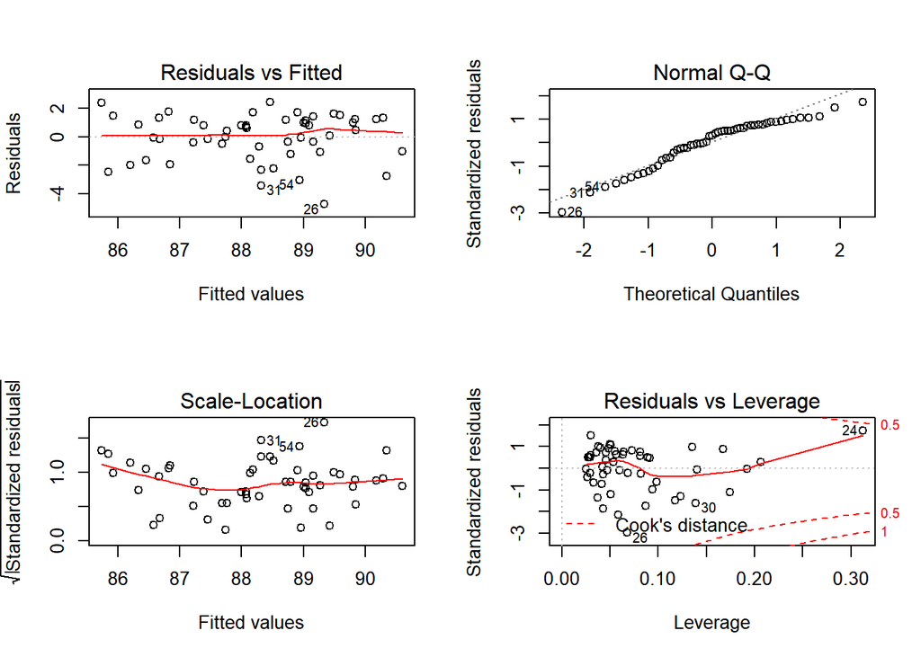

```r
par(mfrow = c(2,2))
plot(prod_lm_4)
```

```r
par(mfrow = c(1,1))
```

Model average milk production using a generalized least squares (gls) model with an autoregressive (AR1) correlation structure

Need complete dataset

`r dairy_data2 <- na.omit(dairy_data) nrow(dairy_data2)`

`## [1] 53`

`r summary(dairy_data2)`

`## DATE Avgmilk FOOTHILLS_DAILYMAXO3 ## Min. :2019-05-02 Min. :83.40 Min. :23.00 ## 1st Qu.:2019-05-17 1st Qu.:87.20 1st Qu.:47.00 ## Median :2019-05-30 Median :88.40 Median :55.00 ## Mean :2019-05-29 Mean :88.27 Mean :52.98 ## 3rd Qu.:2019-06-12 3rd Qu.:89.90 3rd Qu.:59.00 ## Max. :2019-06-26 Max. :91.60 Max. :71.00 ## PM2.5_avg PM2.5_max THI SCC_avg ## Min. : 0.500 Min. : 2.000 Min. :25.77 Min. : 72.00 ## 1st Qu.: 2.667 1st Qu.: 6.000 1st Qu.:49.85 1st Qu.: 83.50 ## Median : 4.043 Median : 7.000 Median :61.08 Median : 88.00 ## Mean : 4.309 Mean : 8.283 Mean :57.19 Mean : 88.99 ## 3rd Qu.: 5.333 3rd Qu.:10.000 3rd Qu.:67.65 3rd Qu.: 96.00 ## Max. :11.875 Max. :26.000 Max. :73.63 Max. :110.00`

Just the time trend

`r prod_0 <- gls(Avgmilk ~ DATE, data = dairy_data2, correlation = corAR1()) summary(prod_0)`

`## Generalized least squares fit by REML ## Model: Avgmilk ~ DATE ## Data: dairy_data2 ## AIC BIC logLik ## 205.6167 213.344 -98.80833 ## ## Correlation Structure: AR(1) ## Formula: ~1 ## Parameter estimate(s): ## Phi ## 0.6295455 ## ## Coefficients: ## Value Std.Error t-value p-value ## (Intercept) -1035.7465 581.8829 -1.779991 0.081 ## DATE 0.0623 0.0322 1.931610 0.059 ## ## Correlation: ## (Intr) ## DATE -1 ## ## Standardized residuals: ## Min Q1 Med Q3 Max ## -2.4692568 -0.6603945 0.3048394 0.7795790 1.3019352 ## ## Residual standard error: 1.954813 ## Degrees of freedom: 53 total; 51 residual`

`r plot(prod_0)`

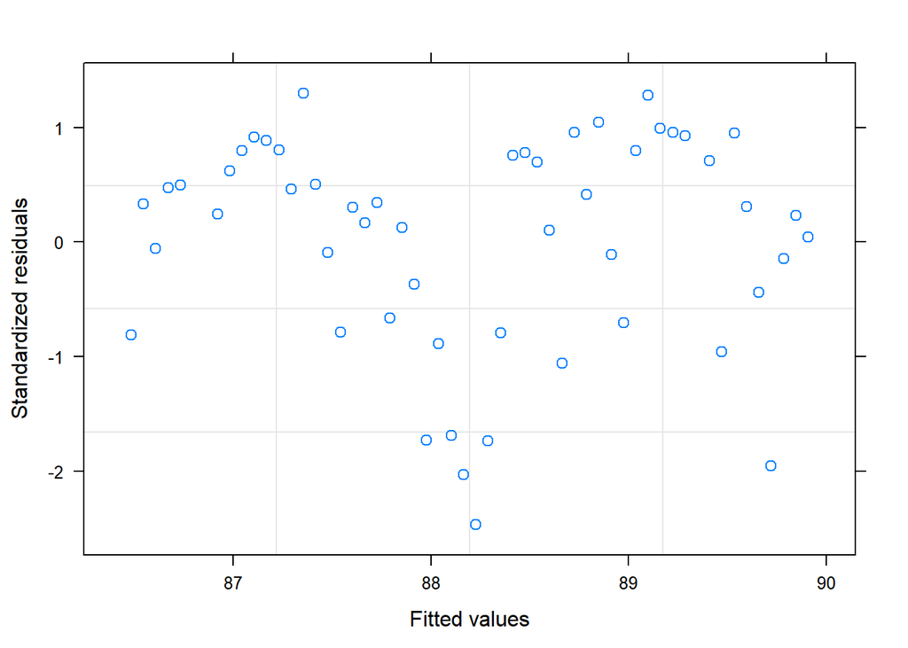

Add temperature

`r prod_1 <- gls(Avgmilk ~ DATE + THI, data = dairy_data2, correlation = corAR1()) summary(prod_1)`

`## Generalized least squares fit by REML ## Model: Avgmilk ~ DATE + THI ## Data: dairy_data2 ## AIC BIC logLik ## 211.1318 220.6919 -100.5659 ## ## Correlation Structure: AR(1) ## Formula: ~1 ## Parameter estimate(s): ## Phi ## 0.6113721 ## ## Coefficients: ## Value Std.Error t-value p-value ## (Intercept) -741.7825 589.5637 -1.258189 0.2142 ## DATE 0.0459 0.0327 1.403032 0.1668 ## THI 0.0367 0.0262 1.400320 0.1676 ## ## Correlation: ## (Intr) DATE ## DATE -1.000 ## THI 0.348 -0.350 ## ## Standardized residuals: ## Min Q1 Med Q3 Max ## -2.4714922 -0.4003497 0.2522842 0.7322124 1.2097599 ## ## Residual standard error: 1.899327 ## Degrees of freedom: 53 total; 50 residual`

`r plot(prod_1)`

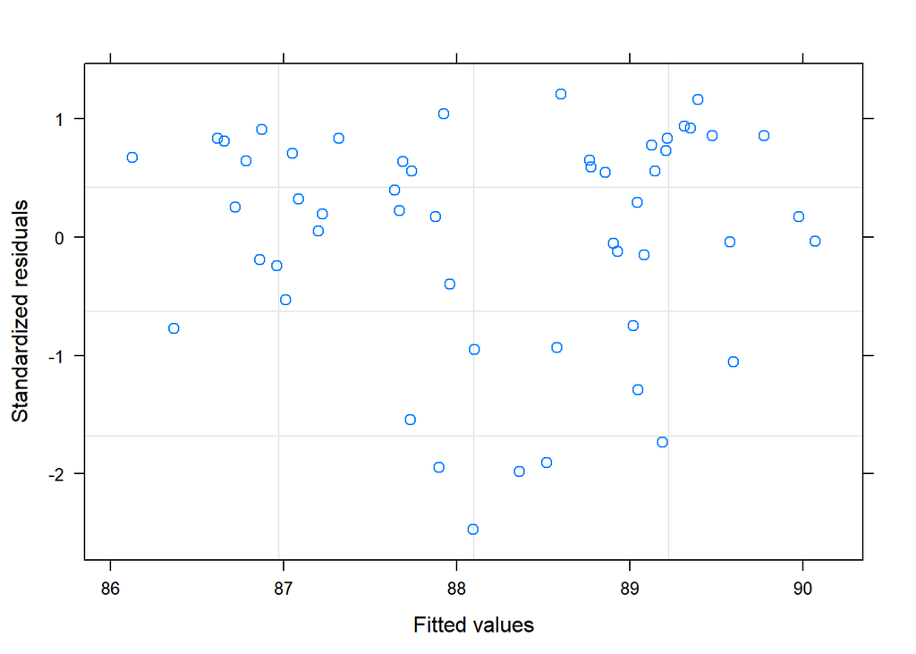

Add ozone

`r prod_2 <- gls(Avgmilk ~ DATE + THI + FOOTHILLS_DAILYMAXO3, data = dairy_data2, correlation = corAR1()) summary(prod_2)`

`## Generalized least squares fit by REML ## Model: Avgmilk ~ DATE + THI + FOOTHILLS_DAILYMAXO3 ## Data: dairy_data2 ## AIC BIC logLik ## 218.0518 229.4027 -103.0259 ## ## Correlation Structure: AR(1) ## Formula: ~1 ## Parameter estimate(s): ## Phi ## 0.5848425 ## ## Coefficients: ## Value Std.Error t-value p-value ## (Intercept) -706.3428 566.7881 -1.2462203 0.2186 ## DATE 0.0439 0.0314 1.3974409 0.1686 ## THI 0.0449 0.0318 1.4114409 0.1644 ## FOOTHILLS_DAILYMAXO3 -0.0137 0.0319 -0.4295921 0.6694 ## ## Correlation: ## (Intr) DATE THI ## DATE -1.000 ## THI 0.350 -0.352 ## FOOTHILLS_DAILYMAXO3 -0.091 0.090 -0.566 ## ## Standardized residuals: ## Min Q1 Med Q3 Max ## -2.4007410 -0.3747236 0.2903414 0.7463361 1.2271963 ## ## Residual standard error: 1.865352 ## Degrees of freedom: 53 total; 49 residual`